# Customer_churn

### Importing Necessary Libraries

```python
import pandas as pd
import numpy as np

import matplotlib.pyplot as plt
import seaborn as sns
import plotly.express as px
from pylab import rcParams

import sklearn
from sklearn.preprocessing import LabelEncoder
from sklearn.preprocessing import MinMaxScaler
from sklearn.model_selection import train_test_split
from sklearn.model_selection import RandomizedSearchCV

from sklearn.svm import SVC
from sklearn.neighbors import KNeighborsClassifier
from sklearn.linear_model import LogisticRegression
from sklearn.ensemble import RandomForestClassifier
from sklearn.ensemble import GradientBoostingClassifier
from xgboost import XGBClassifier

from sklearn import metrics
from sklearn.metrics import accuracy_score
from sklearn.metrics import confusion_matrix
from sklearn.metrics import mutual_info_score
from sklearn.metrics import classification_report
from sklearn.metrics import precision_score, recall_score
```

```python
plt.style.use('fivethirtyeight')
%matplotlib inline
rcParams['figure.figsize'] = 15,6
sns.set_style('whitegrid')
```

### Loading and Analyzing Data

```python
df = pd.read_csv('./Data/WA_Fn-UseC_-Telco-Customer-Churn.csv')
df.head()
```

|  | customerID | gender | SeniorCitizen | Partner | Dependents | tenure | PhoneService | MultipleLines | InternetService | OnlineSecurity | ... | DeviceProtection | TechSupport | StreamingTV | StreamingMovies | Contract | PaperlessBilling | PaymentMethod | MonthlyCharges | TotalCharges | Churn |
| --- | --- | --- | --- | --- | --- | --- | --- | --- | --- | --- | --- | --- | --- | --- | --- | --- | --- | --- | --- | --- | --- |
| 0 | 7590-VHVEG | Female | 0 | Yes | No | 1 | No | No phone service | DSL | No | ... | No | No | No | No | Month-to-month | Yes | Electronic check | 29.85 | 29.85 | No |
| 1 | 5575-GNVDE | Male | 0 | No | No | 34 | Yes | No | DSL | Yes | ... | Yes | No | No | No | One year | No | Mailed check | 56.95 | 1889.5 | No |
| 2 | 3668-QPYBK | Male | 0 | No | No | 2 | Yes | No | DSL | Yes | ... | No | No | No | No | Month-to-month | Yes | Mailed check | 53.85 | 108.15 | Yes |
| 3 | 7795-CFOCW | Male | 0 | No | No | 45 | No | No phone service | DSL | Yes | ... | Yes | Yes | No | No | One year | No | Bank transfer (automatic) | 42.30 | 1840.75 | No |
| 4 | 9237-HQITU | Female | 0 | No | No | 2 | Yes | No | Fiber optic | No | ... | No | No | No | No | Month-to-month | Yes | Electronic check | 70.70 | 151.65 | Yes |

5 rows × 21 columns

```python
# Checking unique entries and data type of each column

print(' Information About Columns \n\n')
for i in df.columns:
    print('{} - Data Type : {} - Unique Values: {}'.format(i, df[i].dtype, df[i].unique()))
```

```
 Information About Columns


customerID - Data Type : object - Unique Values: ['7590-VHVEG' '5575-GNVDE' '3668-QPYBK' ... '4801-JZAZL' '8361-LTMKD'
 '3186-AJIEK']
gender - Data Type : object - Unique Values: ['Female' 'Male']
SeniorCitizen - Data Type : int64 - Unique Values: [0 1]
Partner - Data Type : object - Unique Values: ['Yes' 'No']
Dependents - Data Type : object - Unique Values: ['No' 'Yes']
tenure - Data Type : int64 - Unique Values: [ 1 34  2 45  8 22 10 28 62 13 16 58 49 25 69 52 71 21 12 30 47 72 17 27
  5 46 11 70 63 43 15 60 18 66  9  3 31 50 64 56  7 42 35 48 29 65 38 68
 32 55 37 36 41  6  4 33 67 23 57 61 14 20 53 40 59 24 44 19 54 51 26  0
 39]
PhoneService - Data Type : object - Unique Values: ['No' 'Yes']
MultipleLines - Data Type : object - Unique Values: ['No phone service' 'No' 'Yes']
InternetService - Data Type : object - Unique Values: ['DSL' 'Fiber optic' 'No']
OnlineSecurity - Data Type : object - Unique Values: ['No' 'Yes' 'No internet service']
OnlineBackup - Data Type : object - Unique Values: ['Yes' 'No' 'No internet service']
DeviceProtection - Data Type : object - Unique Values: ['No' 'Yes' 'No internet service']
TechSupport - Data Type : object - Unique Values: ['No' 'Yes' 'No internet service']
StreamingTV - Data Type : object - Unique Values: ['No' 'Yes' 'No internet service']
StreamingMovies - Data Type : object - Unique Values: ['No' 'Yes' 'No internet service']
Contract - Data Type : object - Unique Values: ['Month-to-month' 'One year' 'Two year']
PaperlessBilling - Data Type : object - Unique Values: ['Yes' 'No']
PaymentMethod - Data Type : object - Unique Values: ['Electronic check' 'Mailed check' 'Bank transfer (automatic)'
 'Credit card (automatic)']
MonthlyCharges - Data Type : float64 - Unique Values: [29.85 56.95 53.85 ... 63.1  44.2  78.7 ]
TotalCharges - Data Type : object - Unique Values: ['29.85' '1889.5' '108.15' ... '346.45' '306.6' '6844.5']
Churn - Data Type : object - Unique Values: ['No' 'Yes']
```

Other than the CustomerID and Target variable Churn, the dataset have 19 independent variables. These can be broadly calssified into 3 groups.

1. Demographic Information ('gender', 'SeniorCitizen', 'Partner', 'Dependents')
2. Customer Account Information ('tenure', 'Contract', 'PaperlessBilling', 'PaymentMethod', 'MonthlyCharges', 'TotalCharges')
3. Services Information ('PhoneService', 'MultipleLines', 'InternetService', 'OnlineSecurity', 'OnlineBackup', 'DeviceProtection', 'TechSupport', 'StreamingTV', 'StreamingMovies')

### Exploratory Data Analysis and Cleaning

```python
df.info()
```

```
<class 'pandas.core.frame.DataFrame'>
RangeIndex: 7043 entries, 0 to 7042
Data columns (total 21 columns):
 #   Column            Non-Null Count  Dtype
---  ------            --------------  -----
 0   customerID        7043 non-null   object
 1   gender            7043 non-null   object
 2   SeniorCitizen     7043 non-null   int64
 3   Partner           7043 non-null   object
 4   Dependents        7043 non-null   object
 5   tenure            7043 non-null   int64
 6   PhoneService      7043 non-null   object
 7   MultipleLines     7043 non-null   object
 8   InternetService   7043 non-null   object
 9   OnlineSecurity    7043 non-null   object
 10  OnlineBackup      7043 non-null   object
 11  DeviceProtection  7043 non-null   object
 12  TechSupport       7043 non-null   object
 13  StreamingTV       7043 non-null   object
 14  StreamingMovies   7043 non-null   object
 15  Contract          7043 non-null   object
 16  PaperlessBilling  7043 non-null   object
 17  PaymentMethod     7043 non-null   object
 18  MonthlyCharges    7043 non-null   float64
 19  TotalCharges      7043 non-null   object
 20  Churn             7043 non-null   object
dtypes: float64(1), int64(2), object(18)
memory usage: 1.1+ MB
```

We can see from here that the, column "Total Charges" is object type. However, this column represents the total amount charged to the customer. Hence, it needs to be changed into a numeric data type

```python
# Changing data type of TotalCharges

df['TotalCharges'] = pd.to_numeric(df['TotalCharges'], errors = 'coerce')

# By default, this function raises an exception when it sees non-numeric data;
# however, we can use the argument errors='coerce' to skip those cases and replace them with a NaN.
```

```python
df.isnull().sum()
```

```
customerID           0
gender               0
SeniorCitizen        0
Partner              0
Dependents           0
tenure               0
PhoneService         0
MultipleLines        0
InternetService      0
OnlineSecurity       0
OnlineBackup         0
DeviceProtection     0
TechSupport          0
StreamingTV          0
StreamingMovies      0
Contract             0
PaperlessBilling     0
PaymentMethod        0
MonthlyCharges       0
TotalCharges        11
Churn                0
dtype: int64
```

We can see that the TotalCharges column now has 11 missing data. lets find those rows

```python
df[df['TotalCharges'].isnull()]
```

|  | customerID | gender | SeniorCitizen | Partner | Dependents | tenure | PhoneService | MultipleLines | InternetService | OnlineSecurity | ... | DeviceProtection | TechSupport | StreamingTV | StreamingMovies | Contract | PaperlessBilling | PaymentMethod | MonthlyCharges | TotalCharges | Churn |
| --- | --- | --- | --- | --- | --- | --- | --- | --- | --- | --- | --- | --- | --- | --- | --- | --- | --- | --- | --- | --- | --- |
| 488 | 4472-LVYGI | Female | 0 | Yes | Yes | 0 | No | No phone service | DSL | Yes | ... | Yes | Yes | Yes | No | Two year | Yes | Bank transfer (automatic) | 52.55 | NaN | No |
| 753 | 3115-CZMZD | Male | 0 | No | Yes | 0 | Yes | No | No | No internet service | ... | No internet service | No internet service | No internet service | No internet service | Two year | No | Mailed check | 20.25 | NaN | No |
| 936 | 5709-LVOEQ | Female | 0 | Yes | Yes | 0 | Yes | No | DSL | Yes | ... | Yes | No | Yes | Yes | Two year | No | Mailed check | 80.85 | NaN | No |
| 1082 | 4367-NUYAO | Male | 0 | Yes | Yes | 0 | Yes | Yes | No | No internet service | ... | No internet service | No internet service | No internet service | No internet service | Two year | No | Mailed check | 25.75 | NaN | No |
| 1340 | 1371-DWPAZ | Female | 0 | Yes | Yes | 0 | No | No phone service | DSL | Yes | ... | Yes | Yes | Yes | No | Two year | No | Credit card (automatic) | 56.05 | NaN | No |
| 3331 | 7644-OMVMY | Male | 0 | Yes | Yes | 0 | Yes | No | No | No internet service | ... | No internet service | No internet service | No internet service | No internet service | Two year | No | Mailed check | 19.85 | NaN | No |
| 3826 | 3213-VVOLG | Male | 0 | Yes | Yes | 0 | Yes | Yes | No | No internet service | ... | No internet service | No internet service | No internet service | No internet service | Two year | No | Mailed check | 25.35 | NaN | No |
| 4380 | 2520-SGTTA | Female | 0 | Yes | Yes | 0 | Yes | No | No | No internet service | ... | No internet service | No internet service | No internet service | No internet service | Two year | No | Mailed check | 20.00 | NaN | No |
| 5218 | 2923-ARZLG | Male | 0 | Yes | Yes | 0 | Yes | No | No | No internet service | ... | No internet service | No internet service | No internet service | No internet service | One year | Yes | Mailed check | 19.70 | NaN | No |
| 6670 | 4075-WKNIU | Female | 0 | Yes | Yes | 0 | Yes | Yes | DSL | No | ... | Yes | Yes | Yes | No | Two year | No | Mailed check | 73.35 | NaN | No |
| 6754 | 2775-SEFEE | Male | 0 | No | Yes | 0 | Yes | Yes | DSL | Yes | ... | No | Yes | No | No | Two year | Yes | Bank transfer (automatic) | 61.90 | NaN | No |

11 rows × 21 columns

The MonthlyCharges are not 0 but the TotalCharges are 0. This is contradictory. So, we can drop these rows

```python
df.dropna(inplace=True)
# df = df.reset_index()
```

```python
'Lets drop the CustomerID column'

df.drop(columns='customerID', inplace = True)
df = df.reset_index(drop=True)
df.head()
```

|  | gender | SeniorCitizen | Partner | Dependents | tenure | PhoneService | MultipleLines | InternetService | OnlineSecurity | OnlineBackup | DeviceProtection | TechSupport | StreamingTV | StreamingMovies | Contract | PaperlessBilling | PaymentMethod | MonthlyCharges | TotalCharges | Churn |
| --- | --- | --- | --- | --- | --- | --- | --- | --- | --- | --- | --- | --- | --- | --- | --- | --- | --- | --- | --- | --- |
| 0 | Female | 0 | Yes | No | 1 | No | No phone service | DSL | No | Yes | No | No | No | No | Month-to-month | Yes | Electronic check | 29.85 | 29.85 | No |
| 1 | Male | 0 | No | No | 34 | Yes | No | DSL | Yes | No | Yes | No | No | No | One year | No | Mailed check | 56.95 | 1889.50 | No |
| 2 | Male | 0 | No | No | 2 | Yes | No | DSL | Yes | Yes | No | No | No | No | Month-to-month | Yes | Mailed check | 53.85 | 108.15 | Yes |
| 3 | Male | 0 | No | No | 45 | No | No phone service | DSL | Yes | No | Yes | Yes | No | No | One year | No | Bank transfer (automatic) | 42.30 | 1840.75 | No |
| 4 | Female | 0 | No | No | 2 | Yes | No | Fiber optic | No | No | No | No | No | No | Month-to-month | Yes | Electronic check | 70.70 | 151.65 | Yes |

```python
df['PaymentMethod'].unique()
```

```
array(['Electronic check', 'Mailed check', 'Bank transfer (automatic)',
       'Credit card (automatic)'], dtype=object)
```

Some entries of the column PaymentMethod contains (automatic), which doesnt serve any purpose for our analysis. Lets replace those entries

```python
df['PaymentMethod'] = df['PaymentMethod'].str.replace(' (automatic)', '', regex = False)
df['PaymentMethod'].unique()
```

```
array(['Electronic check', 'Mailed check', 'Bank transfer', 'Credit card'],
      dtype=object)
```

```python
df.info()
```

```
<class 'pandas.core.frame.DataFrame'>
RangeIndex: 7032 entries, 0 to 7031
Data columns (total 20 columns):
 #   Column            Non-Null Count  Dtype
---  ------            --------------  -----
 0   gender            7032 non-null   object
 1   SeniorCitizen     7032 non-null   int64
 2   Partner           7032 non-null   object
 3   Dependents        7032 non-null   object
 4   tenure            7032 non-null   int64
 5   PhoneService      7032 non-null   object
 6   MultipleLines     7032 non-null   object
 7   InternetService   7032 non-null   object
 8   OnlineSecurity    7032 non-null   object
 9   OnlineBackup      7032 non-null   object
 10  DeviceProtection  7032 non-null   object
 11  TechSupport       7032 non-null   object
 12  StreamingTV       7032 non-null   object
 13  StreamingMovies   7032 non-null   object
 14  Contract          7032 non-null   object
 15  PaperlessBilling  7032 non-null   object
 16  PaymentMethod     7032 non-null   object
 17  MonthlyCharges    7032 non-null   float64
 18  TotalCharges      7032 non-null   float64
 19  Churn             7032 non-null   object
dtypes: float64(2), int64(2), object(16)
memory usage: 1.1+ MB
```

### Analysis with Visualization

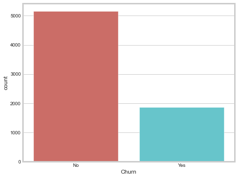

```python
plt.figure(figsize = (7, 6))
sns.countplot(x = 'Churn', data = df, palette = 'hls')
```

It can be observed from the countplot that majority of the responses are NO (almost more than 70%) which makes this dataset imbalance and may impact the prediction accuracy

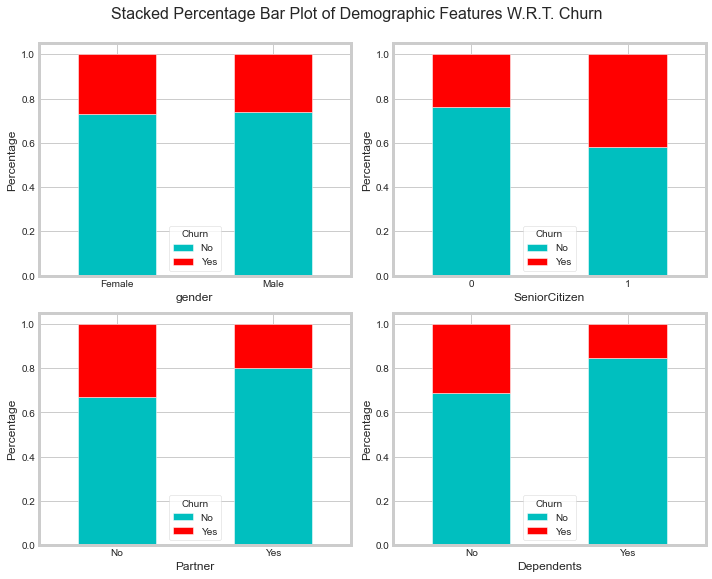

```python
columns = ['gender', 'SeniorCitizen', 'Partner', 'Dependents']

fig = plt.figure(figsize=(10,8))
colors = ['c', 'r']
fig.suptitle('Stacked Percentage Bar Plot of Demographic Features W.R.T. Churn', fontsize=16, y=1)

for i, column in enumerate(columns):
    plt.subplot(2, 2, i + 1)
    data = pd.crosstab(index = df[column], columns = df['Churn'], normalize = 'index')
    data.plot(kind = 'bar', stacked = True, ax = plt.gca(), color = colors)
    plt.xlabel(column)
    plt.ylabel('Percentage')
    plt.xticks(rotation = 0)

plt.tight_layout()
plt.show()
```

This plot gives a very good idea about the impact of demographic featurs on the target variable. Although the gender feature doesnt impact the churn decision much, the rest of the features have significant impact. Like, seniorcitizen are more likely to churn than the youngs whereas customers with partner or dependents are less likely to churn than those who doesnt have partner or dependents.

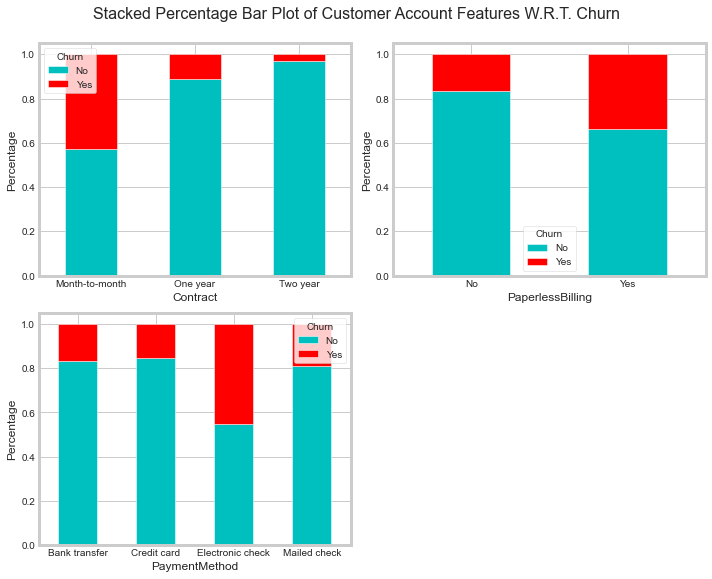

```python
columns = ['Contract', 'PaperlessBilling', 'PaymentMethod']

fig = plt.figure(figsize=(10,8))
colors = ['c', 'r']
fig.suptitle('Stacked Percentage Bar Plot of Customer Account Features W.R.T. Churn', fontsize=16, y=1)

for i, column in enumerate(columns):
    plt.subplot(2, 2, i + 1)
    data = pd.crosstab(index = df[column], columns = df['Churn'], normalize = 'index')
    data.plot(kind = 'bar', stacked = True, ax = plt.gca(), color = colors)
    plt.xlabel(column)
    plt.ylabel('Percentage')
    plt.xticks(rotation = 0)

plt.tight_layout()
plt.show()
```

Here we can see that, customers with month-to-month contracts, paperless billing and Electronic Check payment method are more likely to churn than the other of the same categories.

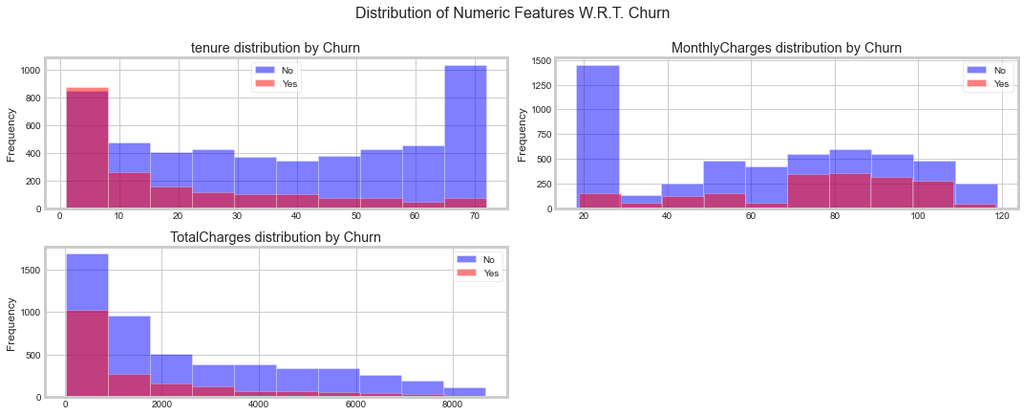

```python
columns = ['tenure', 'MonthlyCharges', 'TotalCharges']

fig = plt.figure()
fig.suptitle('Distribution of Numeric Features W.R.T. Churn', fontsize=16, y=1)

for i, column in enumerate(columns):
    plt.subplot(2,2, i+1)
    df[df['Churn'] == 'No'][column].plot(kind ='hist', alpha=0.5, color='blue', label='No')
    df[df['Churn'] == 'Yes'][column].plot(kind ='hist', alpha=0.5, color='red', label='Yes')
    plt.legend()
    plt.title(f'{column} distribution by Churn')

plt.tight_layout()
plt.show()
```

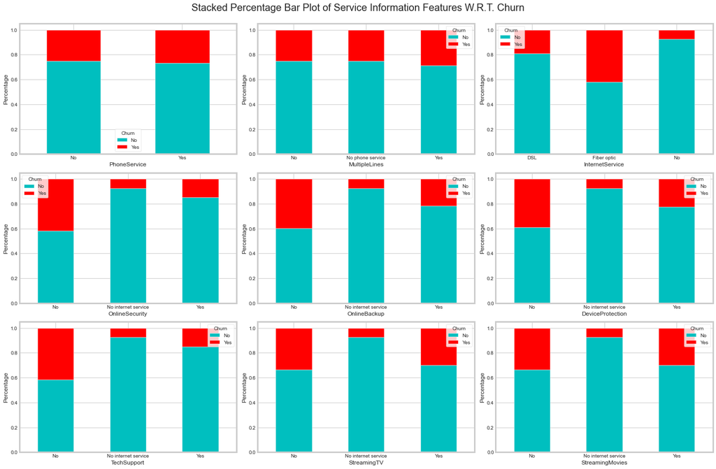

```python
columns = ['PhoneService', 'MultipleLines', 'InternetService', 'OnlineSecurity',
                   'OnlineBackup', 'DeviceProtection', 'TechSupport', 'StreamingTV', 'StreamingMovies']

fig = plt.figure(figsize=(20,13))
fig.suptitle('Stacked Percentage Bar Plot of Service Information Features W.R.T. Churn', fontsize=20, y=1)
colors = ['c', 'r']

for i, column in enumerate(columns):
    plt.subplot(3, 3, i + 1)
    data = pd.crosstab(index = df[column], columns = df['Churn'], normalize = 'index')      # creating a crosstab data frame
    data.plot(kind = 'bar', stacked = True, ax = plt.gca(), color = colors)
    plt.xlabel(column)
    plt.ylabel('Percentage')
    plt.xticks(rotation=0)

plt.tight_layout()
plt.show()
```

Phone attributes (PhoneService and MultipleLines) do not have significant predictive power. The percentage of churn for all classes in both independent variables is nearly the same. Clients with online security and device protection churn less than those without it. Customers with no tech support tend to churn more often than those with tech support.

### Feature Importance

```python
# Computing mutual information score between the categorical variables and response variable

categorical_variables = df.select_dtypes(include = object).drop('Churn', axis = 1)

def compute_mutual_info_score(cat_variable):
    return mutual_info_score(cat_variable, df.Churn)

feature_importance = categorical_variables.apply(compute_mutual_info_score).sort_values()
feature_importance
```

```
gender              0.000037
PhoneService        0.000069
MultipleLines       0.000798
Partner             0.011383
Dependents          0.014270
PaperlessBilling    0.019119
StreamingTV         0.031803
StreamingMovies     0.031918
DeviceProtection    0.043784
PaymentMethod       0.044423
OnlineBackup        0.046659
InternetService     0.055394
TechSupport         0.062873
OnlineSecurity      0.064528
Contract            0.098182
dtype: float64
```

```python
fig = px.bar(feature_importance, orientation = 'h', width = 800, height = 500)
fig.update_layout(xaxis_title = 'Importance',
                  yaxis_title = 'Categorcal Features',
                  title = 'Categorical Feature Importance',
                  title_x = 0.5, title_y = 0.95)
```

[output not shown]

The feature importance scores are in line with our preliminary data analysis. From the scores we can tell that, the gender, PhoneService and MultipleLines features do not have strong relationship with the target variable. Therefore we may drop these columns.

```python
df.drop(columns = ['gender', 'PhoneService', 'MultipleLines'], inplace = True)
df = df.reset_index(drop = True)
df.head()
```

|  | SeniorCitizen | Partner | Dependents | tenure | InternetService | OnlineSecurity | OnlineBackup | DeviceProtection | TechSupport | StreamingTV | StreamingMovies | Contract | PaperlessBilling | PaymentMethod | MonthlyCharges | TotalCharges | Churn |
| --- | --- | --- | --- | --- | --- | --- | --- | --- | --- | --- | --- | --- | --- | --- | --- | --- | --- |
| 0 | 0 | Yes | No | 1 | DSL | No | Yes | No | No | No | No | Month-to-month | Yes | Electronic check | 29.85 | 29.85 | No |
| 1 | 0 | No | No | 34 | DSL | Yes | No | Yes | No | No | No | One year | No | Mailed check | 56.95 | 1889.50 | No |
| 2 | 0 | No | No | 2 | DSL | Yes | Yes | No | No | No | No | Month-to-month | Yes | Mailed check | 53.85 | 108.15 | Yes |
| 3 | 0 | No | No | 45 | DSL | Yes | No | Yes | Yes | No | No | One year | No | Bank transfer | 42.30 | 1840.75 | No |
| 4 | 0 | No | No | 2 | Fiber optic | No | No | No | No | No | No | Month-to-month | Yes | Electronic check | 70.70 | 151.65 | Yes |

### Feature Engineering

```python
# We need to encode the categiracal variables in order to pass them to the ML algorithms
# We will encode the partner, dependents, PaperlessBilling, and Churn variables with labelencoder

columns = ['Partner', 'Dependents', 'PaperlessBilling', 'Churn']

label_encoder = LabelEncoder()

for column in columns:
    df[column] = label_encoder.fit_transform(df[column])

df.head()
```

|  | SeniorCitizen | Partner | Dependents | tenure | InternetService | OnlineSecurity | OnlineBackup | DeviceProtection | TechSupport | StreamingTV | StreamingMovies | Contract | PaperlessBilling | PaymentMethod | MonthlyCharges | TotalCharges | Churn |
| --- | --- | --- | --- | --- | --- | --- | --- | --- | --- | --- | --- | --- | --- | --- | --- | --- | --- |
| 0 | 0 | 1 | 0 | 1 | DSL | No | Yes | No | No | No | No | Month-to-month | 1 | Electronic check | 29.85 | 29.85 | 0 |
| 1 | 0 | 0 | 0 | 34 | DSL | Yes | No | Yes | No | No | No | One year | 0 | Mailed check | 56.95 | 1889.50 | 0 |
| 2 | 0 | 0 | 0 | 2 | DSL | Yes | Yes | No | No | No | No | Month-to-month | 1 | Mailed check | 53.85 | 108.15 | 1 |
| 3 | 0 | 0 | 0 | 45 | DSL | Yes | No | Yes | Yes | No | No | One year | 0 | Bank transfer | 42.30 | 1840.75 | 0 |
| 4 | 0 | 0 | 0 | 2 | Fiber optic | No | No | No | No | No | No | Month-to-month | 1 | Electronic check | 70.70 | 151.65 | 1 |

```python
# We will encode the Contract, PaymentMethod, InternetServices, OnlineSecurity, OnlineBackup, DeviceProtection,
# TechSupport, StreamingTV, and StreamingMovies variables with Onehotencoder or pandas get_dummies function

one_hot_encoding_columns = ['InternetService', 'OnlineSecurity', 'OnlineBackup', 'DeviceProtection',
                            'TechSupport', 'StreamingTV',  'StreamingMovies', 'Contract', 'PaymentMethod']

df_dummies = pd.get_dummies(df, columns = one_hot_encoding_columns)

df_dummies.head()
```

|  | SeniorCitizen | Partner | Dependents | tenure | PaperlessBilling | MonthlyCharges | TotalCharges | Churn | InternetService_DSL | InternetService_Fiber optic | ... | StreamingMovies_No | StreamingMovies_No internet service | StreamingMovies_Yes | Contract_Month-to-month | Contract_One year | Contract_Two year | PaymentMethod_Bank transfer | PaymentMethod_Credit card | PaymentMethod_Electronic check | PaymentMethod_Mailed check |
| --- | --- | --- | --- | --- | --- | --- | --- | --- | --- | --- | --- | --- | --- | --- | --- | --- | --- | --- | --- | --- | --- |
| 0 | 0 | 1 | 0 | 1 | 1 | 29.85 | 29.85 | 0 | 1 | 0 | ... | 1 | 0 | 0 | 1 | 0 | 0 | 0 | 0 | 1 | 0 |
| 1 | 0 | 0 | 0 | 34 | 0 | 56.95 | 1889.50 | 0 | 1 | 0 | ... | 1 | 0 | 0 | 0 | 1 | 0 | 0 | 0 | 0 | 1 |
| 2 | 0 | 0 | 0 | 2 | 1 | 53.85 | 108.15 | 1 | 1 | 0 | ... | 1 | 0 | 0 | 1 | 0 | 0 | 0 | 0 | 0 | 1 |
| 3 | 0 | 0 | 0 | 45 | 0 | 42.30 | 1840.75 | 0 | 1 | 0 | ... | 1 | 0 | 0 | 0 | 1 | 0 | 1 | 0 | 0 | 0 |
| 4 | 0 | 0 | 0 | 2 | 1 | 70.70 | 151.65 | 1 | 0 | 1 | ... | 1 | 0 | 0 | 1 | 0 | 0 | 0 | 0 | 1 | 0 |

5 rows × 36 columns

Since the numeric variables are on differnt scalse we should normalize them

```python
scaler = MinMaxScaler()

df_scaled = pd.DataFrame(scaler.fit_transform(df_dummies), columns = df_dummies.columns)

df_scaled.head()
```

|  | SeniorCitizen | Partner | Dependents | tenure | PaperlessBilling | MonthlyCharges | TotalCharges | Churn | InternetService_DSL | InternetService_Fiber optic | ... | StreamingMovies_No | StreamingMovies_No internet service | StreamingMovies_Yes | Contract_Month-to-month | Contract_One year | Contract_Two year | PaymentMethod_Bank transfer | PaymentMethod_Credit card | PaymentMethod_Electronic check | PaymentMethod_Mailed check |
| --- | --- | --- | --- | --- | --- | --- | --- | --- | --- | --- | --- | --- | --- | --- | --- | --- | --- | --- | --- | --- | --- |
| 0 | 0.0 | 1.0 | 0.0 | 0.000000 | 1.0 | 0.115423 | 0.001275 | 0.0 | 1.0 | 0.0 | ... | 1.0 | 0.0 | 0.0 | 1.0 | 0.0 | 0.0 | 0.0 | 0.0 | 1.0 | 0.0 |
| 1 | 0.0 | 0.0 | 0.0 | 0.464789 | 0.0 | 0.385075 | 0.215867 | 0.0 | 1.0 | 0.0 | ... | 1.0 | 0.0 | 0.0 | 0.0 | 1.0 | 0.0 | 0.0 | 0.0 | 0.0 | 1.0 |
| 2 | 0.0 | 0.0 | 0.0 | 0.014085 | 1.0 | 0.354229 | 0.010310 | 1.0 | 1.0 | 0.0 | ... | 1.0 | 0.0 | 0.0 | 1.0 | 0.0 | 0.0 | 0.0 | 0.0 | 0.0 | 1.0 |
| 3 | 0.0 | 0.0 | 0.0 | 0.619718 | 0.0 | 0.239303 | 0.210241 | 0.0 | 1.0 | 0.0 | ... | 1.0 | 0.0 | 0.0 | 0.0 | 1.0 | 0.0 | 1.0 | 0.0 | 0.0 | 0.0 |
| 4 | 0.0 | 0.0 | 0.0 | 0.014085 | 1.0 | 0.521891 | 0.015330 | 1.0 | 0.0 | 1.0 | ... | 1.0 | 0.0 | 0.0 | 1.0 | 0.0 | 0.0 | 0.0 | 0.0 | 1.0 | 0.0 |

5 rows × 36 columns

### Splitting the dataset in training and testing sets

```python
X = df_scaled.drop(columns = 'Churn')
y = df_scaled['Churn']
print(X.shape, y.shape)

X_train, X_test, y_train, y_test = train_test_split(X, y, test_size = 0.25, shuffle = True, random_state = 26)
```

```
(7032, 35) (7032,)
```

### Assessing multiple algorithms

We will try different ML algorithm with default hyperparameters and compare thier performance

```python
# Lets create a list of all the models that we are going to test

def create_models(seed=2):
    models = []
    models.append(('k_nearest_neighbors', KNeighborsClassifier()))
    models.append(('logistic_regression', LogisticRegression(random_state=seed)))
    models.append(('support_vector_machines', SVC(random_state=seed)))
    models.append(('random_forest', RandomForestClassifier(random_state=seed)))
    models.append(('gradient_boosting', GradientBoostingClassifier(random_state=seed)))
    models.append(('xg_boost', XGBClassifier(random_state=seed)))

    return models

models = create_models()
```

```python
# Lets test the accuracy of each model using default hyperparameters

results = []
names = []

for name, model in models:
    model.fit(X_train, y_train)
    predictions = model.predict(X_test)
    accuracy = accuracy_score(y_test, predictions)
    results.append(accuracy)
    names.append(name)
    print('Classifier: {}, Accuracy: {})'.format(name, accuracy))
```

```
Classifier: k_nearest_neighbors, Accuracy: 0.7582480091012515)
Classifier: logistic_regression, Accuracy: 0.7923777019340159)
Classifier: support_vector_machines, Accuracy: 0.78839590443686)
Classifier: random_forest, Accuracy: 0.7878270762229806)
Classifier: gradient_boosting, Accuracy: 0.7935153583617748)
Classifier: xg_boost, Accuracy: 0.7792946530147895)
```

### Hyperparameter tuning: Gradient Boosting Classifier

```python
# define the parameter grid
param_grid = {'n_estimators': np.arange(50, 600, 25),
              'max_depth': np.arange(2, 10),
              'max_features': [None, 'sqrt', 'log2'],
              'min_samples_split': np.arange(2, 20, 2),
              'min_samples_leaf': np.arange(1, 10)}

GBC_random_search = RandomizedSearchCV(estimator=GradientBoostingClassifier(),
                                   param_distributions=param_grid,
                                   cv=5, n_iter=150, n_jobs=-1)

GBC_random_search.fit(X_train, y_train)

# print best parameter after tuning
print(GBC_random_search.best_params_)
```

```
{'n_estimators': 225, 'min_samples_split': 2, 'min_samples_leaf': 3, 'max_features': 'sqrt', 'max_depth': 2}
```

```python
# make the predictions
GBC_random_search_predictions = GBC_random_search.predict(X_test)

# construct the confusion matrix
pd.DataFrame(confusion_matrix(y_test, GBC_random_search_predictions),
             columns=['Predicted_No', 'Predicted_Yes'],
             index=['Actual_No', 'Actual_Yes'])
```

|  | Predicted_No | Predicted_Yes |
| --- | --- | --- |
| Actual_No | 1146 | 140 |
| Actual_Yes | 220 | 252 |

```python
print(classification_report(y_test, GBC_random_search_predictions))
```

```
              precision    recall  f1-score   support

         0.0       0.84      0.89      0.86      1286
         1.0       0.64      0.53      0.58       472

    accuracy                           0.80      1758
   macro avg       0.74      0.71      0.72      1758
weighted avg       0.79      0.80      0.79      1758
```

```python
print(accuracy_score(y_test, GBC_random_search_predictions))
```

```
0.7952218430034129
```

The Hyperparmeter tuning has hardly improved the model performance.

### Hyperparameter Tuning: XGB Classifier

```python
# define the parameter grid
grid_parameters = {'n_estimators': np.arange(50, 600, 25),
                   'max_depth': np.arange(2, 10),
                   'subsample': [0.6, 0.8, 1.0],
                   'colsample_bytree': [0.4, 0.6, 0.8, 1.0],
                   'learning_rate': [0.01, 0.05, 0.1, 0.15, 0.2, 0.25, 0.3]}

XGB_random_search = RandomizedSearchCV(estimator = XGBClassifier(),
                                       param_distributions = grid_parameters,
                                       cv = 5, n_iter = 150, n_jobs = -1)

XGB_random_search.fit(X_train, y_train)

# print best parameter after tuning
print(XGB_random_search.best_params_)
```

```
{'subsample': 0.6, 'n_estimators': 150, 'max_depth': 3, 'learning_rate': 0.05, 'colsample_bytree': 0.6}
```

```python
# make the predictions
XGB_random_search_predictions = XGB_random_search.predict(X_test)

# construct the confusion matrix
pd.DataFrame(confusion_matrix(y_test, XGB_random_search_predictions),
             columns=['Predicted_No', 'Predicted_Yes'],
             index=['Actual_No', 'Actual_Yes'])
```

|  | Predicted_No | Predicted_Yes |
| --- | --- | --- |
| Actual_No | 1144 | 142 |
| Actual_Yes | 218 | 254 |

```python
print(classification_report(y_test, XGB_random_search_predictions))
```

```
              precision    recall  f1-score   support

         0.0       0.84      0.89      0.86      1286
         1.0       0.64      0.54      0.59       472

    accuracy                           0.80      1758
   macro avg       0.74      0.71      0.72      1758
weighted avg       0.79      0.80      0.79      1758
```

```python
print(accuracy_score(y_test, XGB_random_search_predictions))
```

```
0.7952218430034129
```

We can see that the hyperparameter tuning has improved the model performance by almost 2%.

### Hyperparameter Tuning: Random Forest

```python
# define the parameter grid
param_grid = {'n_estimators': np.arange(50, 600, 25),
              'max_depth': np.arange(2, 10),
              'min_samples_split': np.arange(2, 20, 2),
              'min_samples_leaf': np.arange(1, 10),
              'max_features': [None, 'sqrt', 'log2'],
              'bootstrap': [True, False],
              'class_weight': ['balanced', None],
              'criterion': ['gini']}

RF_random_search = RandomizedSearchCV(estimator=RandomForestClassifier(),
                                   param_distributions=param_grid,
                                   cv = 5, n_iter = 150, n_jobs = -1)

RF_random_search.fit(X_train, y_train)

# print best parameter after tuning
print(RF_random_search.best_params_)
```

```
{'n_estimators': 125, 'min_samples_split': 2, 'min_samples_leaf': 9, 'max_features': 'sqrt', 'max_depth': 9, 'criterion': 'gini', 'class_weight': None, 'bootstrap': True}
```

```python
# make the predictions
RF_random_search_predictions = RF_random_search.predict(X_test)

# construct the confusion matrix
pd.DataFrame(confusion_matrix(y_test, RF_random_search_predictions),
             columns=['Predicted_No', 'Predicted_Yes'],
             index=['Actual_No', 'Actual_Yes'])
```

|  | Predicted_No | Predicted_Yes |
| --- | --- | --- |
| Actual_No | 1153 | 133 |
| Actual_Yes | 229 | 243 |

```python
print(classification_report(y_test, RF_random_search_predictions))
```

```
              precision    recall  f1-score   support

         0.0       0.83      0.90      0.86      1286
         1.0       0.65      0.51      0.57       472

    accuracy                           0.79      1758
   macro avg       0.74      0.71      0.72      1758
weighted avg       0.78      0.79      0.79      1758
```

```python
print(accuracy_score(y_test, RF_random_search_predictions))
```

```
0.7940841865756542
```